# Homework 1 Solutions

Yi Liu

`June 9`

```r
library(datasets)
library(dplyr)
library("DT")
library(scales)
library(data.table)
library(class)
```

```r
data(Hitters)
```

## Question 1 (2 points)

We will be using Rstudio in this class to implement the algorithms we learn in class. The goal of this assignment is to get you proficient in the basics of R, such as writing scripts and plotting. If you are having trouble, you can find help by searching the internet (often searching for the specific error message is helpful), reading Data Mining with R by Luis Torgo or R in a Nutshell by Joseph Adler, asking your friends, and coming to office hours. The computing homework needs to be submitted with your name and Uni# with Rmarkdown file and a pdf with the code and explanation.

Install the **R** and **RStudio** programs on your computer. Then, inside of RStudio, use the **install.packages** function to install **RMarkdown**. Then, in the code chunk below, type **version**.

```r
version
```

```
               _
platform       x86_64-apple-darwin15.6.0
arch           x86_64
os             darwin15.6.0
system         x86_64, darwin15.6.0
status
major          3
minor          4.1
year           2017
month          06
day            30
svn rev        72865
language       R
version.string R version 3.4.1 (2017-06-30)
nickname       Single Candle
```

## Question 2 (10 points)

### 2a (5 points)

Write a function called **even.or.odd**. Its parameter **x** will be a numeric vector. Return a character vector that says “odd” for odd numbers and “even” for the even numbers. The results should correctly classify every value. To determine if a number is even or odd, you can use the modulus operator **%%** (e.g.: 5%%3 = 2). Note: Try to find a solution that uses vector logic instead of a for loop. In R, this is a good programming practice that will speed up your programs.

Display the results of this function on the vector 1:5.

```r
even.or.odd <- function(x) {
    (x%%2) == 0
}
x <- 1:5
result <- factor(even.or.odd(x), labels = c("Odd", "Even"))
result
```

```
[1] Odd  Even Odd  Even Odd
Levels: Odd Even
```

### 2b (5 points)

Write a function **my.sum** that computes the sum of a numeric vector **x**. The user can also specify **the.type** as a character. If **the.type** is “even”, the function will compute the sum of only the even values in **x**. If **the.type** is “odd”, the function will compute the sum of only the odd values in **x**. If **the.type** is “all”, the function will compute the sum of the entire vector **x**. Within the function, you may use the built-in **sum** function. The function should omit missing values (NA) from the sum. This can be done using the **na.rm** argument within the **sum** function.

Display the results of this function for **odd**, **even**, and **all** values of the vector 1:5.

```r
my.sum <- function(x, the.type) {
    switch(the.type, odd = sum(x[x%%2 == 1]), even = sum(x[x%%2 ==
        0]), all = sum(x))
}

x <- c(1:5)
my.sum(x, the.type = "odd")
```

```
[1] 9
```

```r
my.sum(x, the.type = "even")
```

```
[1] 6
```

```r
my.sum(x, the.type = "all")
```

```
[1] 15
```

## Question 3 (10 points)

Load package **datasets** and load the **iris** data set. We will try to predict the species of iris from the sepal’s length and width and the petal’s length and width using k-nearest neighbors.

### 3a (5 points)

Divide the data into training and testing sets. To do so, let’s create an assignment vector called **training_row**. Each row of the data set will be assigned to the training set (with **training_row** set to TRUE) with probability 0.8 or to the test set (with **training_row** set to FALSE) with probability 0.2. Use the **sample** function to create the **training_row** vector of TRUE and FALSE values. The vector should be as long as the number of rows in the iris data set.

Then, divide the **iris** data set into separate training and test sets according to the **training_row** assignments.

In order to obtain consistent results, we’ll need to set the seed of R’s pseudo-random number generator. To do so, use **set.seed(41)** in the code chunk labeled **constants** above.

```r
data(iris)
summary(iris)
```

```
  Sepal.Length    Sepal.Width     Petal.Length    Petal.Width
 Min.   :4.300   Min.   :2.000   Min.   :1.000   Min.   :0.100
 1st Qu.:5.100   1st Qu.:2.800   1st Qu.:1.600   1st Qu.:0.300
 Median :5.800   Median :3.000   Median :4.350   Median :1.300
 Mean   :5.843   Mean   :3.057   Mean   :3.758   Mean   :1.199
 3rd Qu.:6.400   3rd Qu.:3.300   3rd Qu.:5.100   3rd Qu.:1.800
 Max.   :7.900   Max.   :4.400   Max.   :6.900   Max.   :2.500
       Species
 setosa    :50
 versicolor:50
 virginica :50
```

```r
require(caTools)
set.seed(41)
sample = sample.split(iris, SplitRatio = 0.8)
train = subset(iris, sample == TRUE)
test = subset(iris, sample == FALSE)
```

### 3b (5 points)

Use the function **knn** from the package **class** with **k = 2** to classify the data. What proportion of the values are misclassified on the testing set?

**Note**: In order to use *knn*, the **train** and **test** objects must only include the columns that are used to make the classification. The Species will need to be separated into the **cl** vector and removed from the **train** and **test** objects.

```r
# Build the model
library(class)
knn_model <- knn(train[, -5], test[, -5], cl = train$Species,
    k = 2)
mean(knn_model != test$Species)
```

```
[1] 0.06666667
```

```r
# Inspect 'knn_model'
knn_model
```

```
 [1] setosa     setosa     setosa     setosa     setosa     setosa
 [7] setosa     setosa     setosa     setosa     versicolor versicolor
[13] versicolor versicolor versicolor versicolor versicolor versicolor
[19] versicolor versicolor virginica  versicolor virginica  virginica
[25] virginica  virginica  virginica  virginica  virginica  versicolor
Levels: setosa versicolor virginica
```

*2 are missclassified on the testing set*

## Question 4 (8 points)

Now perform the **knn** classification for each **k** value from 1 to 50. For each value of **k**, compute the percentage of misclassified values on the testing set. Print out your results as a table showing the values of k and the misclassification rates. You can use the **datatable** function in the **DT** package to display an HTML-friendly table.

**Note 1**: It would help to write a function that performs the knn computation and computes the misclassification rates.

**Note 2**: A for loop is one way to perform the computation on each value of k. As a challenge, look at alternative methods of computing the rates. For instance, using the **data.table** package, you could call this function within the data.table grouping **by** each value of k.

```r
# Values of k to use
k <- 1:50
# Check number of k values
train.error <- length(k)
# Fitting models for 50 different k values
for (i in 1:50) {
    knn.model.train <- knn(train[, -5], test[, -5], cl = train$Species,
        k = i, prob = F)
    train.error[i] <- mean(knn.model.train != test$Species)
}

# Print out results
res <- data.frame(train.error)
k.value <- 1:50
res1 <- cbind(k.value, res)
res2 <- datatable(res1, rownames = FALSE)
show(res2)
```

[output not shown]

## Question 5 (20 points)

Use your answers from Question 4 to display the results.

### 5a (5 points)

Plot the misclassification rates on the testing set versus the value of k. Use the **plot** function. Try different values of the arguments (las, xlim, ylim, xlab, ylab, cex, main) to create a nicer display. Use **type = “both”** to display both the points and a line.

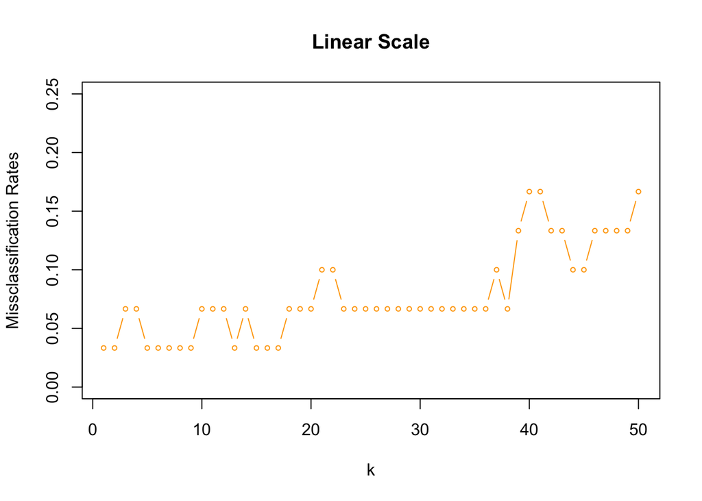

```r
k <- 1:50
plot(k, train.error, xlab = "k", ylab = "Missclassification Rates",
    col = "orange", type = "b", ylim = c(0, 0.25), cex = 0.6,
    main = "Linear Scale")
```

### 5b (5 points)

Now create the same plot placing **k** on a *logarithmic* scale. Make sure to change the label of the x axis to distinguish this.

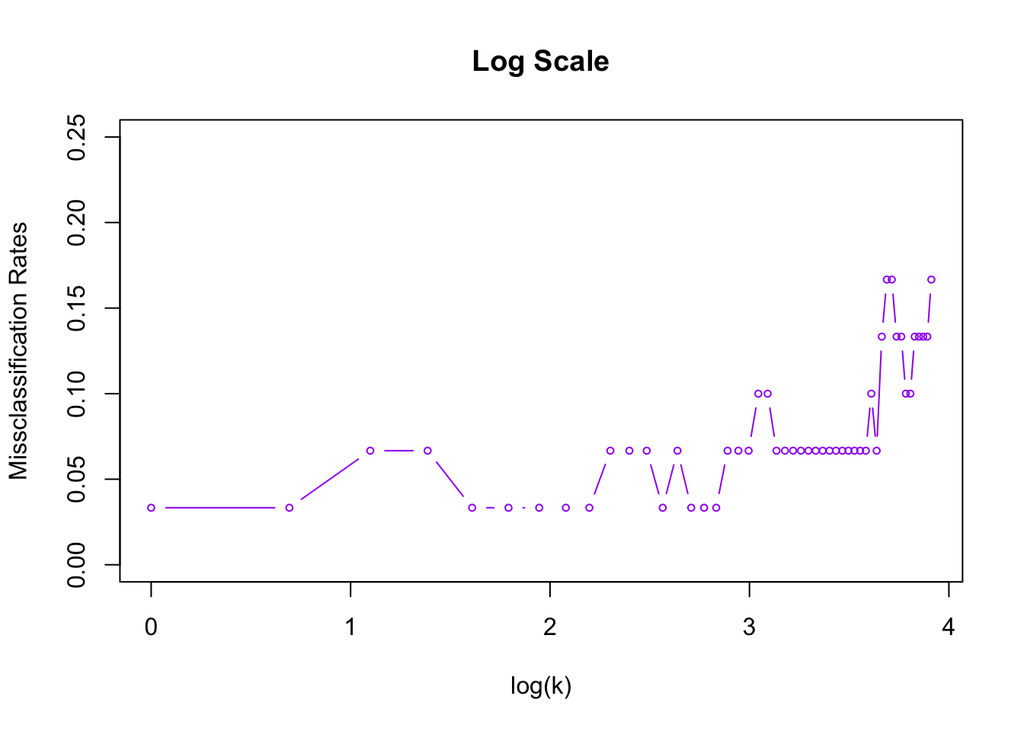

```r
plot(log(k), train.error, xlab = "log(k)", ylab = "Missclassification Rates",
    col = "purple", type = "b", ylim = c(0, 0.25), cex = 0.6,
    main = "Log Scale")
```

### 5c (10 points)

Let’s examine how the results would change if we were to run the knn classifier multiple times. Perform the following steps:

1. Re-perform the previous work 3 more times. Each time, you should create a new training and test set, apply **knn** on each value of **k** from 1 to 50, and compute the misclassification rates on the testing set.
2. Plot the results of the earlier work along with the 3 new iterations on a single plot. Use the **lines** function to add additional lines to the earlier plot from 5a (using the linear scale). Use different colors, line types (lty), and point characters (pch) to distinguish the lines.
3. Use the **legend** command to place a legend in the top left corner (x = “topleft”) of the plot. Use the same colors and point characters to display which line is which. Label the iterations 1 through 4.

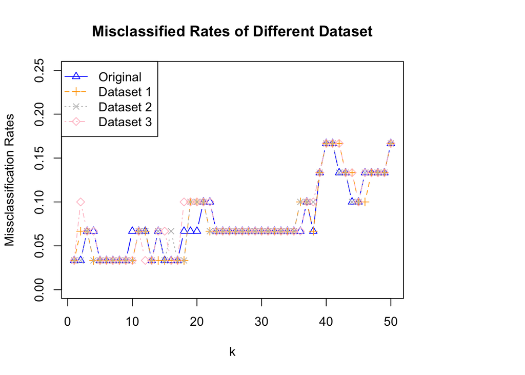

```r
# set seed to make partition
set.seed(41)

sample_1 = sample.split(iris, SplitRatio = 0.8)
train_1 = subset(iris, sample == TRUE)
test_1 = subset(iris, sample == FALSE)

sample_2 = sample.split(iris, SplitRatio = 0.8)
train_2 = subset(iris, sample == TRUE)
test_2 = subset(iris, sample == FALSE)

sample_3 = sample.split(iris, SplitRatio = 0.8)
train_3 = subset(iris, sample == TRUE)
test_3 = subset(iris, sample == FALSE)

miss_cla <- function(trn, tst) {
    for (i in 1:50) {
        knn_model <- knn(train = trn[, -5], test = tst[,
            -5], cl = trn$Species, k = i, prob = F)
        train.error[i] <- mean(knn_model != tst$Species)
    }
    train.error
}

error1 <- miss_cla(train_1, test_1)
error2 <- miss_cla(train_2, test_2)
error3 <- miss_cla(train_3, test_3)

par(mar = c(5.1, 4.1, 4.1, 8.1), xpd = TRUE)
plot(k, train.error, xlab = "k", ylab = "Missclassification Rates",
    main = "Misclassified Rates of Different Dataset", col = "blue",
    type = "b", lty = 1, pch = 2, ylim = c(0, 0.25))

lines(x = k, y = error1, type = "b", col = "orange", lty = 2,
    pch = 3)
lines(x = k, y = error2, type = "b", col = "grey", lty = 3,
    pch = 4)
lines(x = k, y = error3, type = "b", col = "pink", lty = 4,
    pch = 5)

legend("topleft", legend = c("Original", "Dataset 1", "Dataset 2",
    "Dataset 3"), lty = 1:4, col = c("blue", "orange", "grey",
    "pink"), pch = 2:6)
```

## Question 6 (22 points)

Here we’ll work with the Hitters database from the ISLR library, which contains Major League Baseball Data from the 1986 and 1987 seasons (322 observations on 20 variables). For a description of the variables go to: https://rdrr.io/cran/ISLR/man/Hitters.html Install the **ISLR** package in R if you haven’t done so already

### 6a (2 points)

What are the dimensions of the data set?

```r
library(ISLR)
baseball <- Hitters
dim(baseball)
```

```
[1] 322  20
```

### 6b (2 points)

How many salaries are missing (NA)?

```r
sum(is.na(baseball$Salary))  #Count missing salaries (NA)
```

```
[1] 59
```

### 6c (2 points)

What is the maximum number of career home runs?

```r
max(baseball$CHmRun, na.rm = FALSE)
```

```
[1] 548
```

### 6d (2 points)

Compute the **min**, **median**, **mean**, and **max** of Hits, Home Runs, and Runs for this season (not career totals). Remove any missing values from the calculations. Round your results to 1 decimal place.

```r
com <- baseball %>% dplyr::select(Hits, HmRun, Runs)
summaryfun <- function(x) list(Min = min(x), Median = median(x),
    Max = max(x), Mean = mean(x))
sapply(com, summaryfun)
```

```
       Hits     HmRun    Runs
Min    1        0        0
Median 96       8        48
Max    238      40       130
Mean   101.0248 10.77019 50.90994
```

```r
# **min**, **median**, **mean**, and **max** of Hits,
# Home Runs, and Runs for this season
```

### 6e (2 points)

What percentage of these players had at least 100 hits and 20 home runs? Use the **percent** function in the **scales** package to convert a decimal proportion to a percentage.

```r
# Select players had at least 100 hits and 20 home runs
player <- com[which(com$Hits >= 100 & com$HmRun >= 20),
    ]
# Calculate percentage
percent(nrow(player)/nrow(baseball))
```

```
[1] "16.8%"
```

### 6f (2 points)

What is the relationship between different pairs of variables? Let’s look at Salary, Hits, Runs, HmRun, Errors, and Assists. Use the **pairs** function to display scatterplots of each pair of these variables.

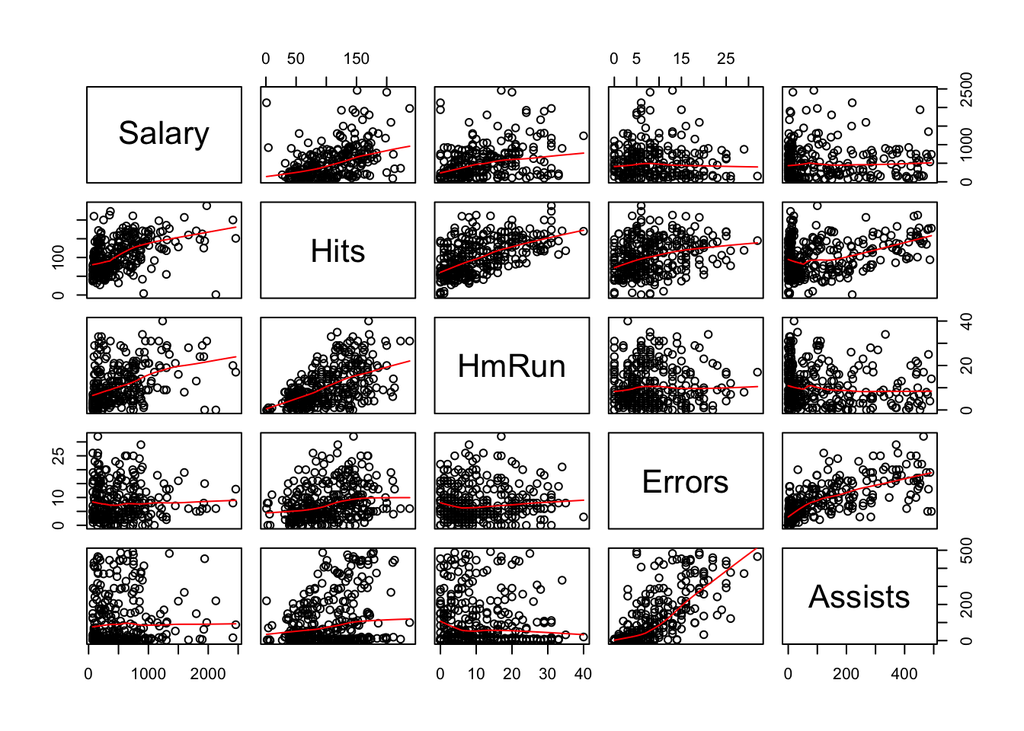

```r
# Relationship between different pairs of variables
pairs(~Salary + Hits + HmRun + Errors + Assists, data = baseball,
    panel = panel.smooth)
```

### 6g (2 points)

Based on these scatterplots, which variables appear to be correlated with Salary, and which ones appear to have little or no correlation with Salary? Provide a short explanation for your assessment.

*Acoording to the scatterplot and the trend line I added in 6f. It is obvious that variables “Hits” and “HmRun” appear to be correlated with “Salary”, while “Erros” and “Assists” appear to have little relationship with “Salary”.*

### 6h (2 points)

Create a new variable called HighRBI for those players with at least 75 RBI (TRUE). Players with less than 75 RBI should have the value FALSE.

```r
attach(baseball)
fun1 <- function(RBI) if (RBI >= 75) {
    "TRUE"
} else {
    "FALSE"
}
baseball$HighRBI <- mapply(fun1, RBI)
```

### 6i (2 points)

What percentage of hitters qualified as HighRBI during these seasons?

```r
percent(nrow(subset(baseball, HighRBI == "TRUE"))/nrow(baseball))
```

```
[1] "18.6%"
```

*18.6% hitters qualified as HighRBI during these seasons*

### 6j (2 points)

What is the correlation of HighRBI, Home Runs, Hits, Runs, Assists, and Errors with Salary? Use only the cases in which both variables are measured. Round the answer to two decimal places.

```r
# Subset players with HighRBI
HRBI <- subset(baseball, RBI >= 75)
# Compute correlations
round(cor(HRBI$RBI, HRBI$Salary, method = "pearson", use = "complete.obs"),
    digits = 2)
```

```
[1] 0.14
```

```r
round(cor(baseball$HmRun, baseball$Salary, method = "pearson",
    use = "complete.obs"), digits = 2)
```

```
[1] 0.34
```

```r
round(cor(baseball$Hits, baseball$Salary, method = "pearson",
    use = "complete.obs"), digits = 2)
```

```
[1] 0.44
```

```r
round(cor(baseball$Runs, baseball$Salary, method = "pearson",
    use = "complete.obs"), digits = 2)
```

```
[1] 0.42
```

```r
round(cor(baseball$Assists, baseball$Salary, method = "pearson",
    use = "complete.obs"), digits = 2)
```

```
[1] 0.03
```

```r
round(cor(baseball$Errors, baseball$Salary, method = "pearson",
    use = "complete.obs"), digits = 2)
```

```
[1] -0.01
```

### 6k (2 points)

How did the salaries differ for players with and without HighRBI? Use the **boxplot** function and **split** the salary data by HighRBI status. Do HighRBI players have a higher median salary?

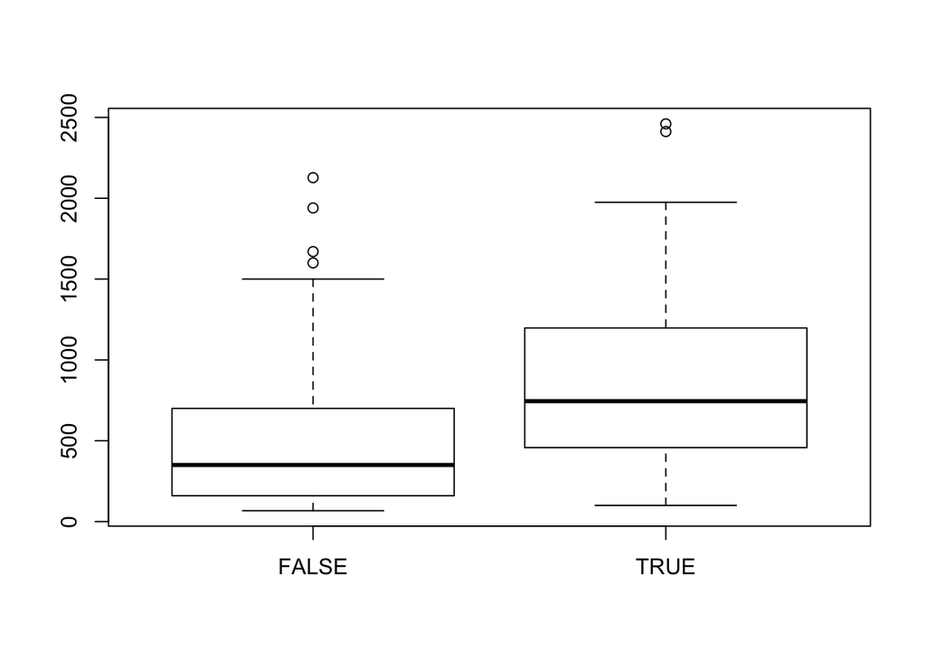

```r
boxplot(Salary ~ HighRBI, data = baseball)
```

*HighRBI people (“TRUE”) have higher median salary as we can see from the boxplot*

### 6l (2 points)

Show a histogram of home runs using the **hist** function with **breaks = 20** and **freq = FALSE**.

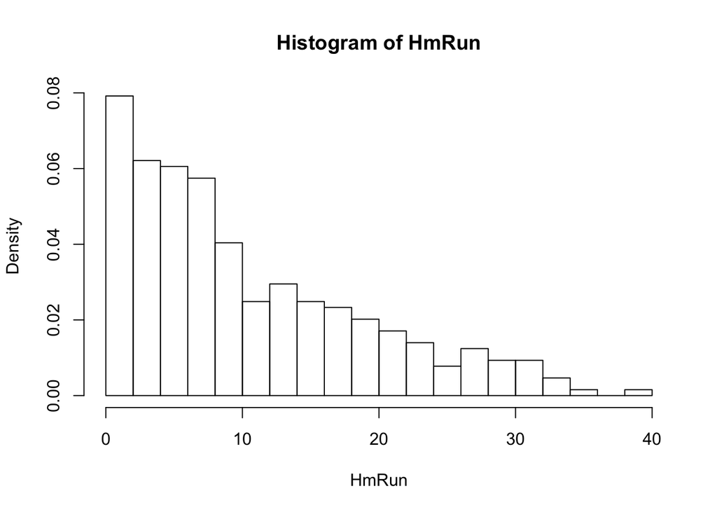

```r
hist(HmRun, breaks = 20, freq = FALSE)
```

## Question 7 (10 points)

### 7a (2 points)

What is the mean and standard deviation of Hits, Runs, Home Runs, RBI, Assists, Errors, and Salaries? Remove any missing values from the calculations. Round the answers to 1 decimal place.

```r
apply(baseball, 2, function(x) any(is.na(x)))  # Test if there any missing value by column
```

```
    AtBat      Hits     HmRun      Runs       RBI     Walks     Years
    FALSE     FALSE     FALSE     FALSE     FALSE     FALSE     FALSE
   CAtBat     CHits    CHmRun     CRuns      CRBI    CWalks    League
    FALSE     FALSE     FALSE     FALSE     FALSE     FALSE     FALSE
 Division   PutOuts   Assists    Errors    Salary NewLeague   HighRBI
    FALSE     FALSE     FALSE     FALSE      TRUE     FALSE     FALSE
```

```r
mscal <- dplyr::select(baseball, Hits, Runs, HmRun, RBI,
    Assists, Errors, Salary)  # Select varaibles
# Ignore NA in mean and stand deviation calculation
rmscal <- sapply(mscal, function(cl) list(means = mean(cl,
    na.rm = TRUE), sds = sd(cl, na.rm = TRUE)))
# Round to 1 decimal
rmscal[] <- lapply(rmscal, function(x) if (is.numeric(x)) format(round(x,
    1), nsmall = 1) else x)
rmscal
```

```
      Hits    Runs   HmRun  RBI    Assists Errors Salary
means "101.0" "50.9" "10.8" "48.0" "106.9" "8.0"  "535.9"
sds   "46.5"  "26.0" "8.7"  "26.2" "136.9" "6.4"  "451.1"
```

### 7b (2 points)

Some players only get to play part-time. Show the mean and standard deviations for the same variables as in the previous question **only for players with at least 300 AtBat**.

```r
ats <- baseball[baseball$AtBat >= 300, ]  # players who has at least 300 AtBats
atscal <- dplyr::select(ats, Hits, Runs, HmRun, RBI, Assists,
    Errors, Salary)  # Select varaibles
# Ignore NA in mean and stand deviation calculation
atmscal <- sapply(atscal, function(cl) list(means = mean(cl,
    na.rm = TRUE), sds = sd(cl, na.rm = TRUE)))
purrr::modify_if(atmscal, ~is.numeric(.), ~round(., 1))  # Round to 1 decimal
```

```
      Hits  Runs HmRun RBI  Assists Errors Salary
means 126.3 64.3 13.8  60.3 133.4   9.4    617.1
sds   35.2  21.3 9     23.2 155     6.8    467.7
```

### 7c (2 points)

Show a scatter plot of Salary versus Home Runs for players with at least 300 AtBat.

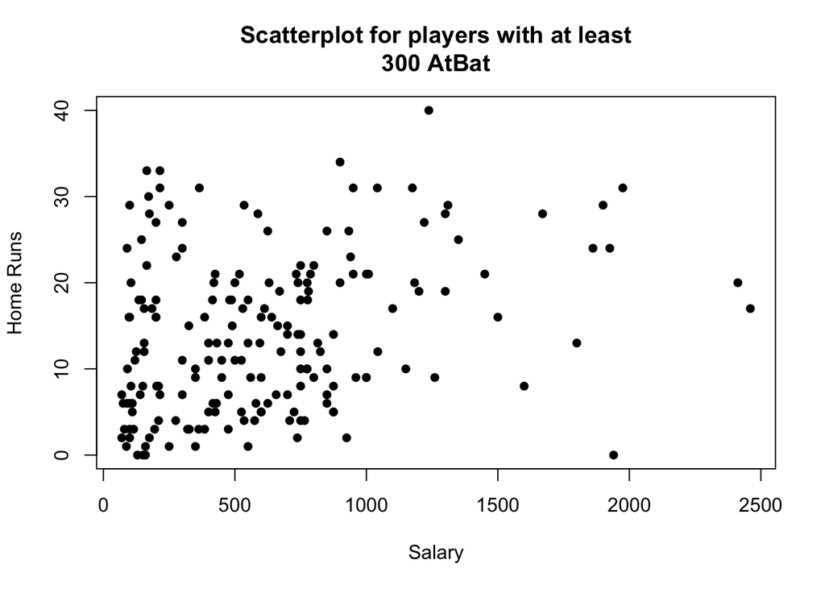

```r
plot(ats$Salary, ats$HmRun, main = "Scatterplot for players with at least
300 AtBat",
    xlab = "Salary", ylab = "Home Runs", pch = 16)
```

### 7d (2 points)

There is a player with zero home runs and a salary over 2,000 (more than 2 million dollars). Who is this player? What does it look like happened during the season? Are these numbers accurate? Use the internet to search for this player’s results in 1986 and 1987.

```r
subset(baseball, HmRun == 0 & Salary > 2000)
```

```
              AtBat Hits HmRun Runs RBI Walks Years CAtBat CHits CHmRun
-Mike Schmidt    20    1     0    0   0     0     2     41     9      2
              CRuns CRBI CWalks League Division PutOuts Assists Errors
-Mike Schmidt     6    7      4      N        E      78     220      6
                Salary NewLeague HighRBI
-Mike Schmidt 2127.333         N   FALSE
```

*Mike Schmidt is the player* *Mike has 0 homeruns, runs, RBI and walks. However, Mike has 20 times at bat in 1986, and 2years in major league. He is not a highRBI player. For season 1986, Mike has 78 put outs, 220 assits and 6 errors. This player’s results are not accurate according to the internet research.*

### 7e (2 points)

Continue exploring the data set. Briefly report (2-3 sentences) on what else you found.

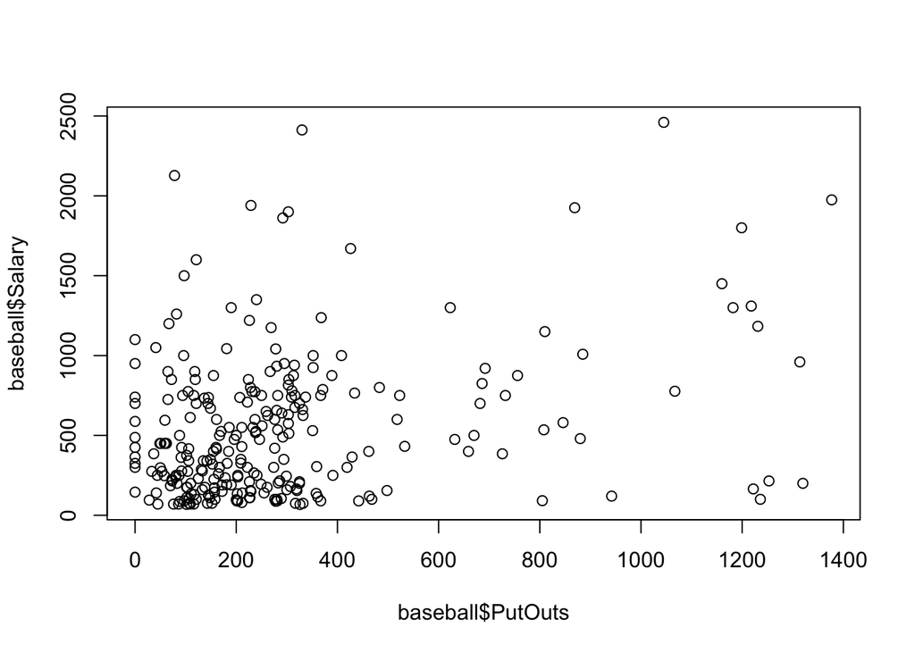

```r
# Explore the relationship of putouts and salary of
# these players
plot(baseball$PutOuts, baseball$Salary)
```

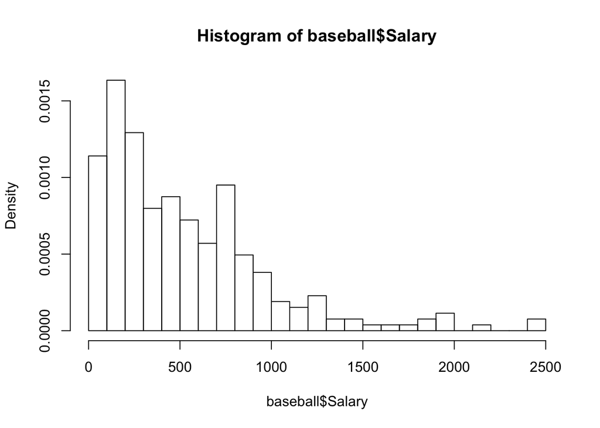

```r
hist(baseball$Salary, breaks = 30, freq = F)
```

*Putouts seems to have a relationship with Salary from the scatterplot. In the histogram, the density of salary shows that the mode number is in 0 to 250.Most players’ putouts are between 0 to 400, and salary lies in 0 to 1000 accordingly.*